# HW 02 - Airbnb listings in Edinburgh

Tina Huynh

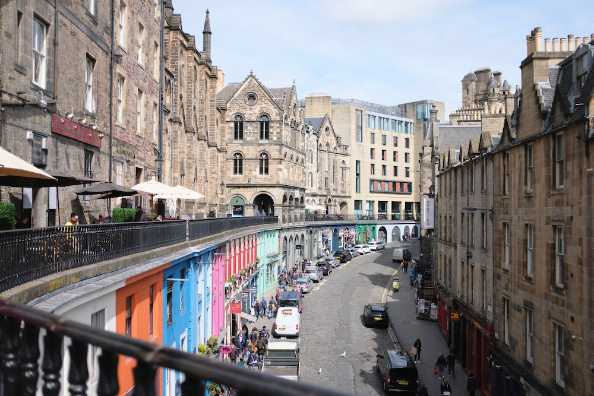

Photo by Madeleine Kohler on Unsplash

Once upon a time, people traveled all over the world, and some stayed in hotels and others chose to stay in other people’s houses that they booked through Airbnb. Recent developments in Edinburgh regarding the growth of Airbnb and its impact on the housing market means a better understanding of the Airbnb listings is needed. Using data provided by Airbnb, we can explore how Airbnb availability and prices vary by neighbourhood.

# Getting started

**IMPORTANT:** If there is no GitHub repo created for you for this assignment, it means I didn’t have your GitHub username as of when I assigned the homework. Please let me know your GitHub username asap, and I can create your repo.

Go to the course GitHub organization and locate your homework repo, which should be named `hw-02-airbnb-edi-YOUR_GITHUB_USERNAME`. Grab the URL of the repo, and clone it in RStudio. First, open the R Markdown document `hw-02.Rmd` and Knit it. Make sure it compiles without errors. The output will be in the file markdown `.md` file with the same name.

## Warm up

Before we introduce the data, let’s warm up with some simple exercises.

- Update the YAML, changing the author name to your name, and **knit** the document.
- Commit your changes with a meaningful commit message.
- Push your changes to GitHub.
- Go to your repo on GitHub and confirm that your changes are visible in your Rmd **and** md files. If anything is missing, commit and push again.

## Packages

We’ll use the **tidyverse** package for much of the data wrangling and visualization and the data lives in the **dsbox** package. These packages are already installed for you. You can load them by running the following in your Console:

```r
install.packages("devtools")
devtools::install_github("tidyverse/dsbox")
library(tidyverse)
library(dsbox)
```

## Data

The data can be found in the **dsbox** package, and it’s called `edibnb`. Since the dataset is distributed with the package, we don’t need to load it separately; it becomes available to us when we load the package.

You can view the dataset as a spreadsheet using the `View()` function. Note that you should not put this function in your R Markdown document, but instead type it directly in the Console, as it pops open a new window (and the concept of popping open a window in a static document doesn’t really make sense…). When you run this in the console, you’ll see the following **data viewer** window pop up.

```r
View(edibnb)
```

You can find out more about the dataset by inspecting its documentation, which you can access by running `?edibnb` in the Console or using the Help menu in RStudio to search for `edibnb`.

# Exercises

**Hint:** The Markdown Quick Reference sheet has an example of inline R code that might be helpful. You can access it from the Help menu in RStudio.

1. How many observations (rows) does the dataset have? 13245 entities in total
2. Run `View(edibnb)` in your Console to view the data in the data viewer. What does each row in the dataset represent?  
   **Each data row represents a listing for an Airbnb rental in Edinburgh.**

🧶 ✅ ⬆️ *Knit,* *commit, and push your changes to GitHub with an appropriate commit message. Make sure to commit and push all changed files so that your Git pane is cleared up afterwards.*

We can get a list of the variables in the data frame using the `names()` function.

```r
names(edibnb)
```

```
##  [1] "id"                   "price"                "neighbourhood"
##  [4] "accommodates"         "bathrooms"            "bedrooms"
##  [7] "beds"                 "review_scores_rating" "number_of_reviews"
## [10] "listing_url"
```

You can find descriptions of each of the variables in the help file for the dataset, which you can access by running `?edibnb` in your Console.

**Note:** The plot will give a warning about some observations with non-finite values for price being removed. Don’t worry about the warning, it simply means that 199 listings in the data didn’t have prices available, so they can’t be plotted.

1. Create a faceted histogram where each facet represents a neighbourhood and displays the distribution of Airbnb prices in that neighbourhood. Think critically about whether it makes more sense to stack the facets on top of each other in a column, lay them out in a row, or wrap them around. Along with your visualization, include your reasoning for the layout you chose for your facets.

```
## Warning: Removed 199 rows containing non-finite outside the scale range
## (`stat_bin()`).
```

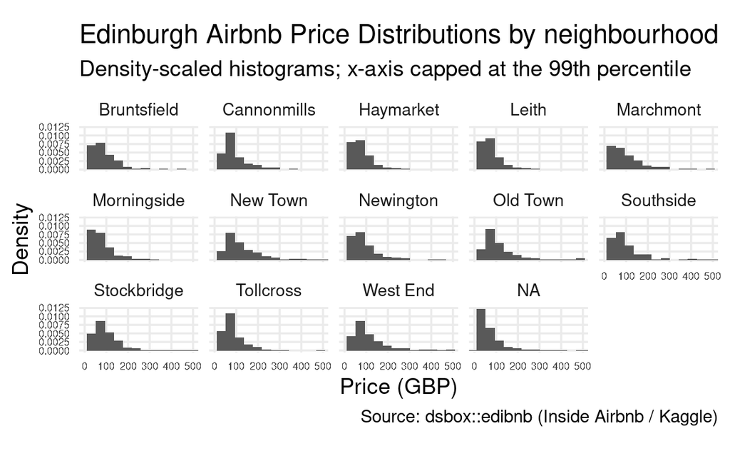

```r
ggplot(edibnb, aes(x = price)) +
  geom_histogram(aes(y = after_stat(density)), bins = 25, boundary = 10, closed = "left") +
  coord_cartesian(xlim = c(0, quantile(edibnb$price, 0.99, na.rm = TRUE))) +
  facet_wrap(~ neighbourhood, ncol = 5) +
  labs(
    title = "Edinburgh Airbnb Price Distributions by neighbourhood",
    subtitle = "Density-scaled histograms; x-axis capped at the 99th percentile",
    x = "Price (GBP)",
    y = "Density",
    caption = "Source: dsbox::edibnb (Inside Airbnb / Kaggle)"
  ) +
  theme_minimal(base_size = 13) +
  theme(
    strip.text = element_text(size = 10),
    panel.grid.minor = element_blank(),
    axis.text = element_text(size = 6),
    plot.margin = unit(c(0.5, 0.25, 0.5, 0.25), "cm")
  )
```

Let’s de-construct this code:

- `ggplot()` is the function we are using to build our plot, in layers.
- In the first layer we always define the data frame as the first argument. Then, we define the mappings between the variables in the dataset and the **aes**thetics of the plot (e.g. x and y coordinates, colours, etc.).
- In the next layer we represent the data with **geom**etric shapes, in this case with a histogram. You should decide what makes a reasonable bin width for the histogram by trying out a few options.
- In the final layer we facet the data by neighbourhood.

I chose to use `facet_wrap()` with 5 columns because:

1. Edinburgh has multiple neighborhoods, and wrapping them allows for better use of the horizontal space than a single column or row. This way, we can see more neighborhoods at once without excessive scrolling.
2. With 5 columns, each facet is still large enough to see the distribution clearly and not too compressed.
3. This layout makes it easier to compare neighborhoods at a glance than stacking them in a column. Therefore, it is more efficient for visual comparison.
4. The wrapped layout provides a good balance between detail and overall comparison view because it avoids excessive white space that would occur with too few columns.

🧶 ✅ ⬆️ Knit, *commit, and push your changes to GitHub with an appropriate commit message. Make sure to commit and push all changed files so that your Git pane is cleared up afterwards.*

4. Use a single pipeline to identity the neighbourhoods with the top five median listing prices. Then, in another pipeline filter the data for these five neighbourhoods and make ridge plots of the distributions of listing prices in these five neighbourhoods. In a third pipeline calculate the minimum, mean, median, standard deviation, IQR, and maximum listing price in each of these neighbourhoods. Use the visualization and the summary statistics to describe the distribution of listing prices in the neighbourhoods. (Your answer will include three pipelines, one of which ends in a visualization, and a narrative.)

```r
top5_neighbourhoods <- edibnb %>%
  filter(!is.na(price), price > 0, !is.na(neighbourhood)) %>%
  group_by(neighbourhood) %>%
  summarize(median_price = median(price, na.rm = TRUE)) %>%
  arrange(desc(median_price)) %>%
  slice_head(n = 5)

top5_neighbourhoods
```

| neighbourhood | median_price |
| --- | --- |
| New Town | 100 |
| Old Town | 90 |
| West End | 90 |
| Stockbridge | 85 |
| Bruntsfield | 80 |

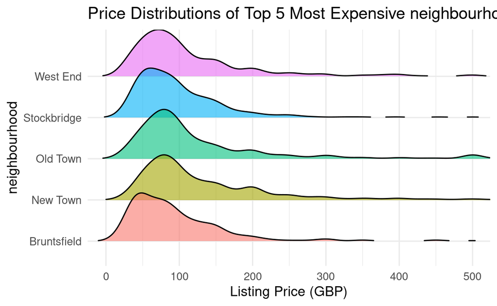

```r
library(ggridges)

edibnb %>%
  filter(!is.na(price), price > 0, neighbourhood %in% top5_neighbourhoods$neighbourhood) %>%
  ggplot(aes(x = price, y = neighbourhood, fill = neighbourhood)) +
  geom_density_ridges(alpha = 0.6, scale = 1.2, rel_min_height = 0.01) +
  coord_cartesian(xlim = c(0, quantile(dsbox::edibnb$price, 0.99, na.rm = TRUE))) +
  labs(
    title = "Price Distributions of Top 5 Most Expensive neighbourhoods in Edinburgh",
    x = "Listing Price (GBP)",
    y = "neighbourhood"
  ) +
  theme_minimal(base_size = 12) +
  theme(legend.position = "none")
```

```r
summary_stats <- edibnb %>%
  filter(!is.na(price), price > 0, neighbourhood %in% top5_neighbourhoods$neighbourhood) %>%
  group_by(neighbourhood) %>%
  summarize(
    min_price = min(price, na.rm = TRUE),
    mean_price = mean(price, na.rm = TRUE),
    median_price = median(price, na.rm = TRUE),
    sd_price = sd(price, na.rm = TRUE),
    iqr_price = IQR(price, na.rm = TRUE),
    max_price = max(price, na.rm = TRUE)
  )

summary_stats
```

| neighbourhood | min_price | mean_price | median_price | sd_price | iqr_price | max_price |
| --- | --- | --- | --- | --- | --- | --- |
| Bruntsfield | 10 | 99.43554 | 80 | 90.17486 | 72.5 | 900 |
| New Town | 12 | 135.63567 | 100 | 108.58782 | 86.5 | 999 |
| Old Town | 15 | 127.52035 | 90 | 109.56948 | 76.0 | 999 |
| Stockbridge | 21 | 103.52749 | 85 | 77.56500 | 66.0 | 750 |
| West End | 19 | 115.69261 | 90 | 93.31377 | 80.0 | 999 |

The price distributions in all five neighborhoods demonstrate pronounced positive skewness, characterized by a concentration of listings at moderate price points with an extended tail toward higher values. This asymmetry suggests a market structure where most properties maintain accessible pricing while a select subset commands premium rates.

Old Town, despite its status as a primary tourist destination, presents a slightly lower median price (£90) compared to New Town, while maintaining comparable variability (standard deviation of £109.57). This pattern may reflect the neighborhood’s mixed accommodation offerings, from heritage buildings to more contemporary developments. The area’s tourism appeal evidently supports elevated price points, with maximum values reaching £999.

The minimum listing prices remain relatively consistent across all five neighborhoods (ranging from £10-£21), indicating that even in Edinburgh’s most exclusive districts, budget accommodation options exist. This accessibility at the lower end contrasts sharply with the maximum values, which reach £999 in multiple neighborhoods, highlighting significant market segmentation.

These pricing patterns reflect Edinburgh’s complex residential landscape, where historical significance, architectural heritage, and proximity to cultural attractions interact to create distinctive neighborhood value propositions. The data suggests that New Town and Old Town command premium pricing due to their central location and historical importance, while areas like Bruntsfield may offer more consistent pricing expectations for both investors and visitors seeking accommodation.

5. Create a visualization that will help you compare the distribution of review scores (`review_scores_rating`) across neighborhoods. You get to decide what type of visualization to create and there is more than one correct answer! In your answer, include a brief interpretation of how Airbnb guests rate properties in general and how the neighborhoods compare to each other in terms of their ratings.

[figure not shown]

```r
ggplot(edibnb %>%
  filter(!is.na(review_scores_rating), !is.na(neighbourhood)) %>%
  mutate(
    neighbourhood = fct_reorder(neighbourhood, review_scores_rating, .fun = median, .na_rm = TRUE)
  ), aes(x = neighbourhood, y = review_scores_rating)) +
  geom_boxplot(fill = "steelblue", alpha = 0.6, outlier.alpha = 0.3) +
  coord_flip() +
  labs(
    title = "Distribution of Airbnb Review Scores by neighbourhood in Edinburgh",
    x = "neighbourhood",
    y <- "Review Score (0-100)"
  ) +
  theme_minimal(base_size = 12) +
  theme(
    panel.grid.minor = element_blank(),
    axis.text.y = element_text(size = 9)
  )
```

The visualization of review score distributions reveals nuanced patterns in guest satisfaction across Edinburgh’s diverse neighborhoods. Examination of the boxplots indicates a predominantly positive guest experience throughout the city, with most neighborhoods achieving median ratings exceeding 90 on the 100-point scale. This high baseline suggests Edinburgh’s Airbnb market generally delivers satisfactory accommodations regardless of location.

The remarkably compressed interquartile ranges observed across most neighborhoods indicate consistency in service quality within each district. This homogeneity suggests established hosting standards within neighborhood communities or similar property types dominating specific areas. The narrow distribution bands also imply reliability in guest experiences, a valuable attribute for travelers selecting accommodations.

While outliers appear across all neighborhoods, their relatively sparse distribution compared to the concentration of positive ratings indicates isolated instances of substandard experiences rather than systemic quality issues. These outliers likely represent properties with specific deficiencies or management problems rather than reflecting neighborhood-wide concerns.

For potential visitors, this analysis provides evidence-based guidance suggesting that excellent accommodation experiences are available throughout Edinburgh, with some less centrally located or lower-priced neighborhoods potentially offering superior guest experiences compared to their more expensive counterparts. For hosts and property managers, these patterns highlight the importance of expectation management and service quality in achieving positive reviews, particularly in high-priced areas where guest expectations may be correspondingly elevated.

🧶 ✅ ⬆️ Knit, *commit, and push your changes to GitHub with an appropriate commit message. Make sure to commit and push all changed files so that your Git pane is cleared up afterwards and review the md document on GitHub to make sure you’re happy with the final state of your work.* Once you decide that you are done with the lab, choose the knit drop down and select `Knit to tufte_handout` to generate a pdf. Download and submit that pdf to Canvas.